# Productivity of ages and types of them.

### import packages

```python
# import all packages and set plots to be embedded inline.
import numpy as np
import pandas as pd
import matplotlib.pyplot as plt
import seaborn as sb

%matplotlib inline
```

### fit size and color

```python
#to fit all figures as the same size.
from matplotlib import rcParams
rcParams['figure.figsize'] = 20,10

#to fit all figures as the same color
base_color = sb.color_palette()[0]
```

### load and handle data (data wrangling)

```python
# load in the dataset into a pandas dataframe, print statistics.
df = pd.read_csv("201902-fordgobike-tripdata.csv")

#fill null values with mean().
df['member_birth_year'].fillna(df['member_birth_year'].mean(), inplace = True)

# fill null values which is Unknown with the name of it.
df['member_gender'].fillna('Unknown', inplace = True)

# fill null values with insight to get the location.
df.fillna('latitude_longitude', inplace = True)
```

### get column age

```python
df['age'] = 2019 - df['member_birth_year']
```

### Explore users Ages

```python
df.age.describe()
```

```
count    183412.000000
mean         34.193563
std           9.886118
min          18.000000
25%          27.000000
50%          32.000000
75%          38.000000
max         141.000000
Name: age, dtype: float64
```

```python
df['age'].value_counts().describe()
```

```
count       76.000000
mean      2413.315789
std       3022.788660
min          1.000000
25%         52.500000
50%       1070.000000
75%       3549.750000
max      10236.000000
Name: age, dtype: float64
```

```python
df['age'].value_counts().head(6)
```

```
31.000000    10236
26.000000     9325
30.000000     8972
29.000000     8658
28.000000     8498
34.193563     8265
Name: age, dtype: int64
```

average of ages is 34 with count 8265 but when we talk to average of count for all years will be 2413 user.

### visualization

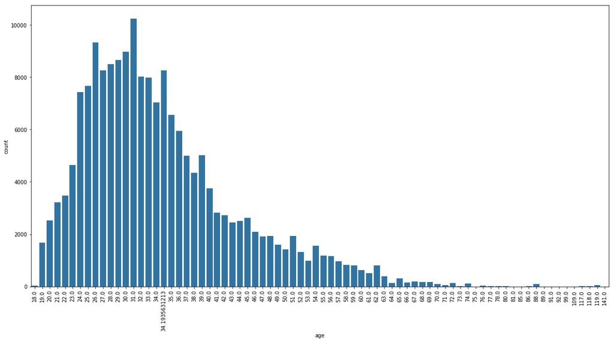

```python
sb.countplot(data = df, x = 'age', color = base_color);
plt.xticks(rotation = 90);
```

the shape of data is right skewd from age 18 to 141 the average of ages is 34 years old. count of age increase from 18 to 31 and then decrease.

```python
count_age = df['age'].value_counts()
count_age = count_age.reset_index()
count_age = count_age.rename(columns = {'index':'age', 'age':'sum of values'})
```

```python
count_age.head()
```

|  | age | sum of values |
| --- | --- | --- |
| 0 | 31.0 | 10236 |
| 1 | 26.0 | 9325 |
| 2 | 30.0 | 8972 |
| 3 | 29.0 | 8658 |
| 4 | 28.0 | 8498 |

```python
count_age.query("age == 18")
```

|  | age | sum of values |
| --- | --- | --- |
| 58 | 18.0 | 34 |

```python
above_mean = count_age[count_age["sum of values"] >= 2413]

above_median = count_age[count_age["sum of values"] >= 1070]
```

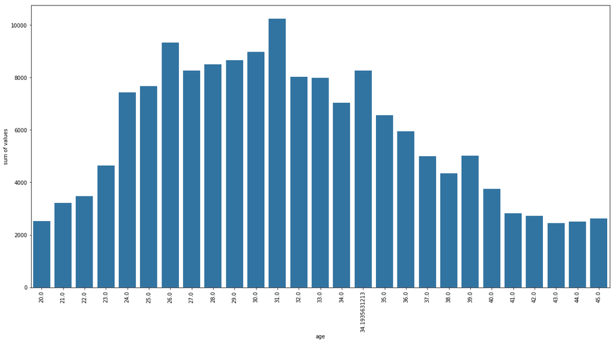

```python
sb.barplot(data = above_mean, x = 'age', y='sum of values', color = base_color);
plt.xticks(rotation = 90);
```

range ages above mean from 20 to 45 years old.

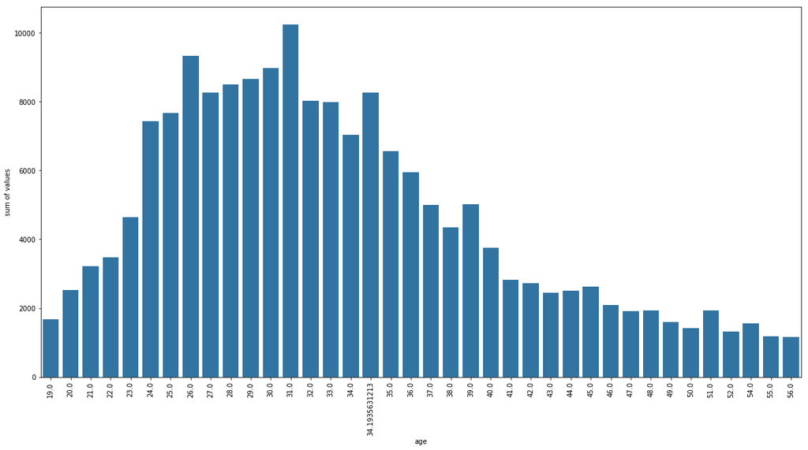

```python
sb.barplot(data = above_median, x = 'age', y='sum of values', color = base_color);
plt.xticks(rotation = 90);
```

range ages above median from 19 to 56 where the destribution is right skewd more than mean.

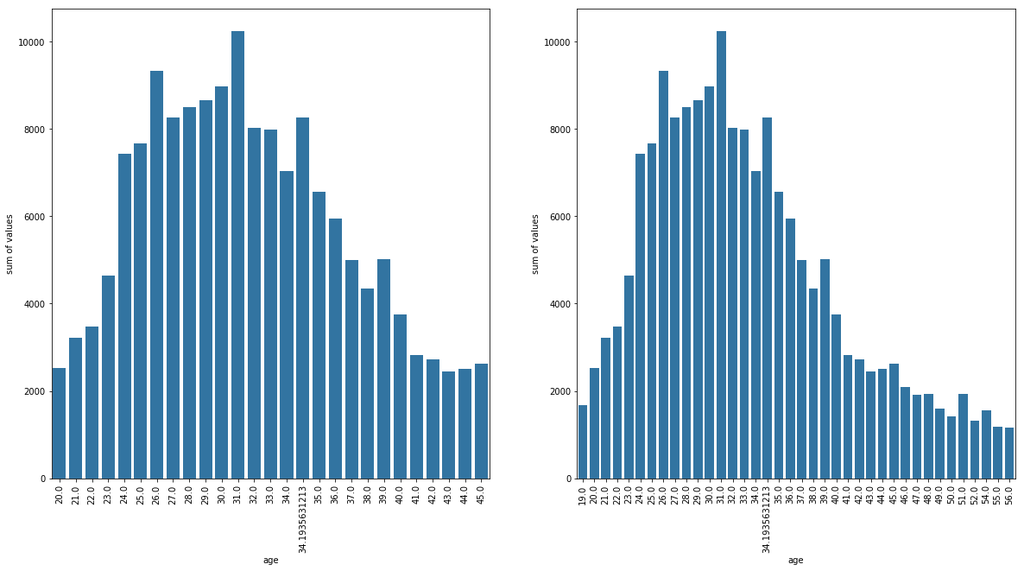

```python
plt.subplot(1,2,1)
sb.barplot(data = above_mean, x = 'age', y='sum of values', color = base_color);
plt.xticks(rotation = 90);

plt.subplot(1,2,2)
sb.barplot(data = above_median, x = 'age', y='sum of values', color = base_color);
plt.xticks(rotation = 90);
```

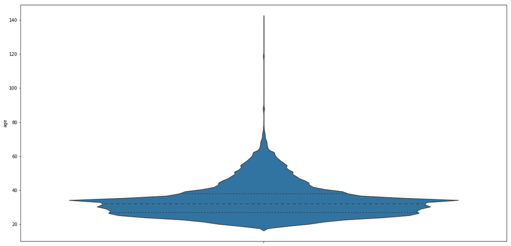

```python
sb.violinplot(data = df, y = 'age', color = base_color, inner = 'quartile');
plt.xticks(rotation = 90);
```

## Top 5 ages count people

```python
df['age'].value_counts().head()
```

```
31.0    10236
26.0     9325
30.0     8972
29.0     8658
28.0     8498
Name: age, dtype: int64
```

26 years old and range from 28 years old to 31 years old is more than others.

### sum counts of top 5 counts

```python
df['age'].value_counts().head().sum()
```

```
45689
```

### sum counts of all data

```python
df['age'].value_counts().sum()
```

```
183412
```

```python
count_age['sum of values'].sum()
```

```
183412
```

### proportion of top 5 ages

```python
df['age'].value_counts().head().sum() / count_age['sum of values'].sum()
```

```
0.24910583822214469
```

approxemately 25% of this data in only 5 ages which are 26 years old and range from 28 years old to 31 years old.

```python
top_05 = df['age'].value_counts().head()
top_11 = df['age'].value_counts().head(11)
top_20 = df['age'].value_counts().head(20)
top_31 = df['age'].value_counts().head(31)

top_05 = top_05.reset_index()
top_11 = top_11.reset_index()
top_20 = top_20.reset_index()
top_31 = top_31.reset_index()

top_05 = top_05.rename(columns = {'index':'age', 'age':'sum of values'})
top_11 = top_11.rename(columns = {'index':'age', 'age':'sum of values'})
top_20 = top_20.rename(columns = {'index':'age', 'age':'sum of values'})
top_31 = top_31.rename(columns = {'index':'age', 'age':'sum of values'})
```

```python
print(top_05['sum of values'].sum() / count_age['sum of values'].sum())
print(top_11['sum of values'].sum() / count_age['sum of values'].sum())
print(top_20['sum of values'].sum() / count_age['sum of values'].sum())
print(top_31['sum of values'].sum() / count_age['sum of values'].sum())
```

```
0.249105838222
0.508570867773
0.758172856738
0.903801277997
```

proportions of data 24.9%, 50.8%, 75.8%, and 90.3%

```python
print(top_05['age'].min(), top_05['age'].max())
print(top_11['age'].min(), top_11['age'].max())
print(top_20['age'].min(), top_20['age'].max())
print(top_31['age'].min(), top_31['age'].max())
```

```
26.0 31.0
24.0 34.1935631213
22.0 40.0
20.0 51.0
```

range ages of this proportions respectivly.

25% of data in this ages {26, [28 : 31]}  
50% of data between 24 years old and 34 years old.  
75% of data between 22 years old and 40 years old.  
90% of data between 20 years old and 51 years old.  
90% of data from 20 to 48 years old and 51 years old.

```python
count_age['sum of values'].value_counts().head(6)
```

```
1       5
807     2
2       2
3       2
11      2
2725    1
Name: sum of values, dtype: int64
```

```python
count_age[count_age['sum of values'] == 1]
```

|  | age | sum of values |
| --- | --- | --- |
| 71 | 91.0 | 1 |
| 72 | 109.0 | 1 |
| 73 | 89.0 | 1 |
| 74 | 92.0 | 1 |
| 75 | 141.0 | 1 |

```python
count_age[count_age['sum of values'] == 2]
```

|  | age | sum of values |
| --- | --- | --- |
| 69 | 85.0 | 2 |
| 70 | 75.0 | 2 |

```python
count_age[count_age['sum of values'] == 3]
```

|  | age | sum of values |
| --- | --- | --- |
| 67 | 81.0 | 3 |
| 68 | 99.0 | 3 |

```python
count_age[count_age['sum of values'] == 11]
```

|  | age | sum of values |
| --- | --- | --- |
| 63 | 117.0 | 11 |
| 64 | 80.0 | 11 |

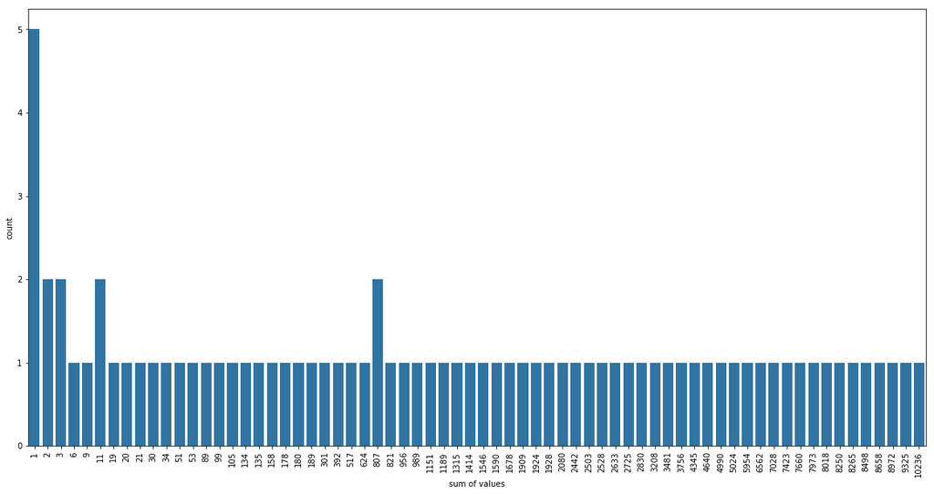

```python
sb.countplot(data = count_age, x = 'sum of values', color = base_color);
plt.xticks(rotation = 90);
```

```python
count_age[count_age['sum of values'] < 100].sort_values('age')
```

|  | age | sum of values |
| --- | --- | --- |
| 58 | 18.0 | 34 |
| 54 | 70.0 | 99 |
| 57 | 71.0 | 51 |
| 62 | 73.0 | 19 |
| 70 | 75.0 | 2 |
| 59 | 76.0 | 30 |
| 60 | 77.0 | 21 |
| 65 | 78.0 | 9 |
| 64 | 80.0 | 11 |
| 67 | 81.0 | 3 |
| 69 | 85.0 | 2 |
| 61 | 86.0 | 20 |
| 55 | 88.0 | 89 |
| 73 | 89.0 | 1 |
| 71 | 91.0 | 1 |
| 74 | 92.0 | 1 |
| 68 | 99.0 | 3 |
| 72 | 109.0 | 1 |
| 63 | 117.0 | 11 |
| 66 | 118.0 | 6 |
| 56 | 119.0 | 53 |
| 75 | 141.0 | 1 |

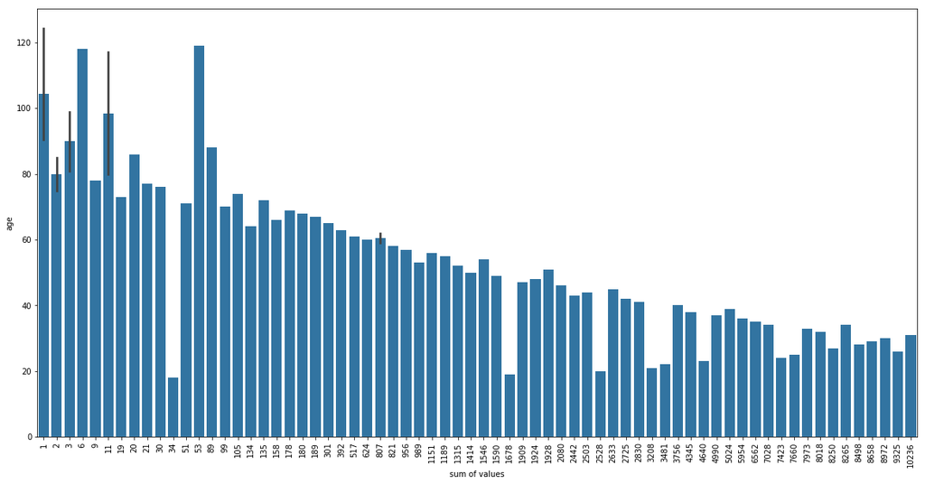

```python
sb.barplot(data = count_age, x = 'sum of values',y='age', color = base_color);
plt.xticks(rotation = 90);
```

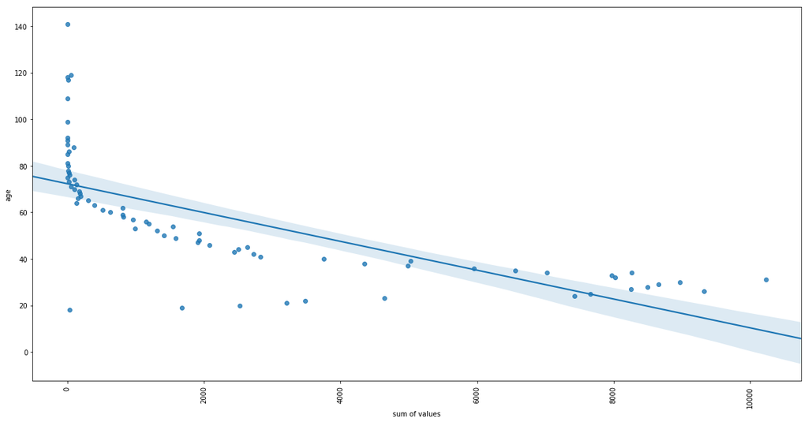

```python
sb.regplot(data = count_age, x = 'sum of values',y='age', color = base_color);
plt.xticks(rotation = 90);
```

the shape above explain when the age increase the count of people in this age decrease.

```python
count_age[count_age['sum of values'] < 100]['sum of values'].sum()
```

```
468
```

```python
(468 / count_age['sum of values'].sum())*100
```

```
0.25516323904651822
```

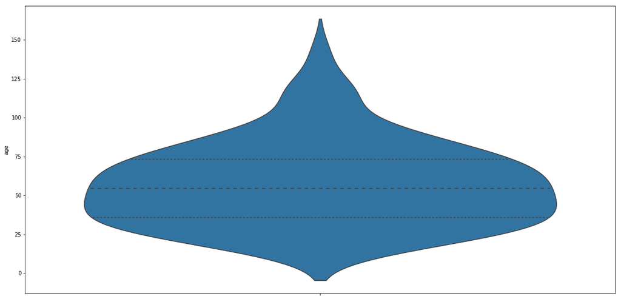

```python
sb.violinplot(data = count_age, y = 'age', color = base_color, inner = 'quartile');
plt.xticks(rotation = 90);
```

approxemately range of counts people between 20 and 80 years old.

# Bivariate

```
Text(0,0.5,'duration of ride bike per/secand')
```

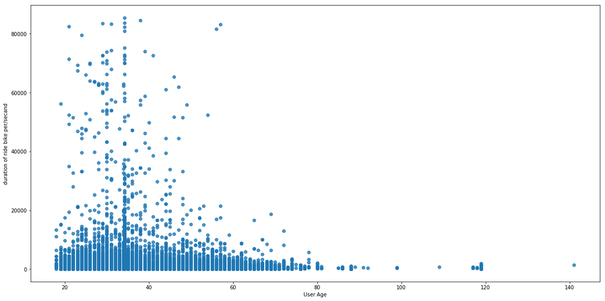

```python
sb.regplot(data = df, x = 'age', y = 'duration_sec', fit_reg=False)
plt.xlabel('User Age')
plt.ylabel('duration of ride bike per/secand')
```

when we talk about duration second in this data approxemately more people between 18 and 65 years old.

```python
df.query("age == 18")['duration_sec'].mean()
```

```
2444.9117647058824
```

```python
df.query("age == 18")['duration_sec'].describe()
```

```
count       34.000000
mean      2444.911765
std       2829.019644
min         73.000000
25%        920.250000
50%       1608.500000
75%       2783.000000
max      13412.000000
Name: duration_sec, dtype: float64
```

```
Text(0,0.5,'duration of ride bike per/secand')
```

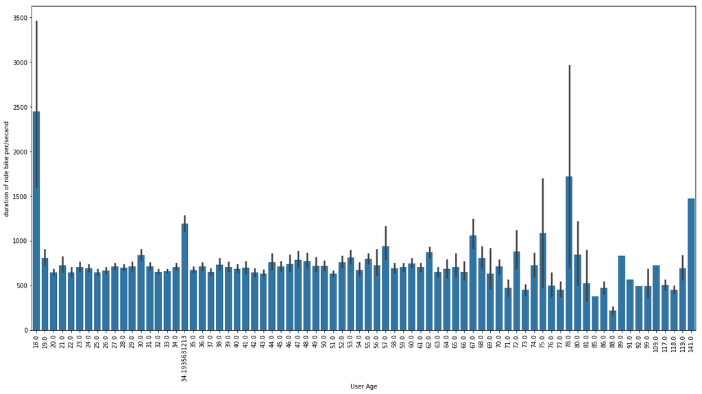

```python
sb.barplot(data = df, x = 'age', y = 'duration_sec', color = base_color)
plt.xticks(rotation = 90)
plt.xlabel('User Age')
plt.ylabel('duration of ride bike per/secand')
```

```python
count_age.query("age == 18")
```

|  | age | sum of values |
| --- | --- | --- |
| 58 | 18.0 | 34 |

average of age 18 years old is greater than others when we talk about duration sec.

when we want more duration second its important to focus on age 18 years old in our marketing. because of average more productive in duration of second and now there only 34 person in this data.

```python
group_age = df.groupby(by="age")
```

```python
count_age_duration = group_age['duration_sec'].sum()
count_age_duration = count_age_duration.drop(count_age_duration.index[17])
count_age_duration = count_age_duration.reset_index()
```

```python
count_age_duration.head(3)
```

|  | age | duration_sec |
| --- | --- | --- |
| 0 | 18.0 | 83127 |
| 1 | 19.0 | 1351439 |
| 2 | 20.0 | 1636246 |

```
Text(0,0.5,'duration of ride bike per/secand')
```

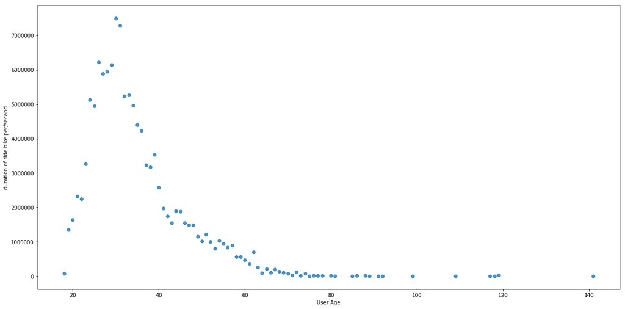

```python
sb.regplot(data = count_age_duration, x = 'age', y = 'duration_sec', fit_reg=False)
plt.xlabel('User Age')
plt.ylabel('duration of ride bike per/secand')
```

```
Text(0,0.5,'duration of ride bike per/secand')
```

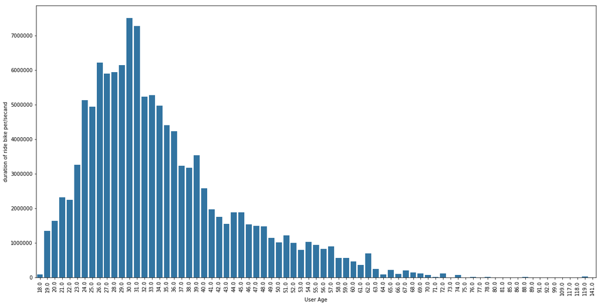

```python
sb.barplot(data = count_age_duration, x = 'age', y = 'duration_sec', color = base_color)
plt.xticks(rotation = 90)
plt.xlabel('User Age')
plt.ylabel('duration of ride bike per/secand')
```

```
Text(0,0.5,'duration of ride bike per/secand')
```

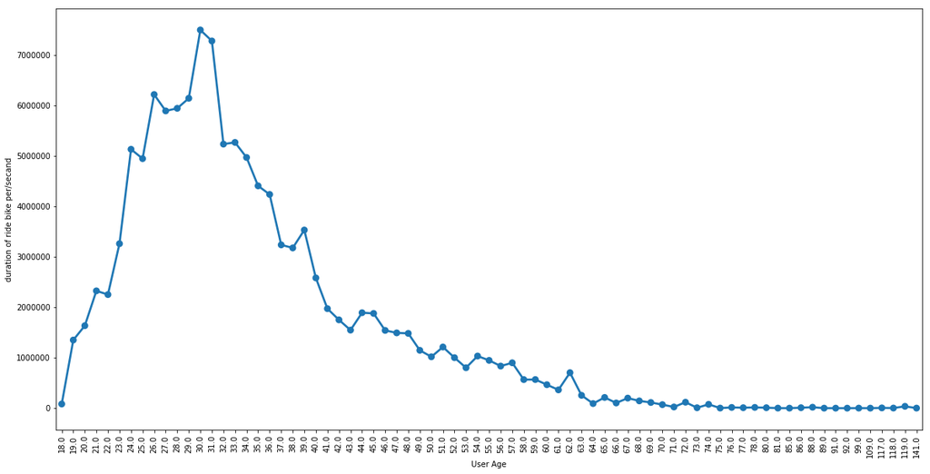

```python
sb.pointplot(data = count_age_duration, x = 'age', y = 'duration_sec')
plt.xticks(rotation = 90)
plt.xlabel('User Age')
plt.ylabel('duration of ride bike per/secand')
```

count duration second is more between 19 and 48 years old from 48 to 63 years old decrease and then be few above 63 years old.

```python
count_age_duration.sort_values('duration_sec', ascending=False).head(6)
```

|  | age | duration_sec |
| --- | --- | --- |
| 12 | 30.0 | 7500881 |
| 13 | 31.0 | 7282470 |
| 8 | 26.0 | 6220997 |
| 11 | 29.0 | 6146255 |
| 10 | 28.0 | 5946938 |
| 9 | 27.0 | 5895635 |

```python
count_age_duration.sort_values('duration_sec', ascending=False).head(6).sum()
```

```
age                  171.0
duration_sec    38993176.0
dtype: float64
```

```python
38993176 / count_age_duration['duration_sec'].sum()
```

```
0.31614228023163699
```

sum of duration better in this range of ages 26:31 years old which its porporthion of duration_sec is 31.6% .

```python
better_duration = count_age_duration.sort_values('duration_sec', ascending=False).head(6)
```

```
Text(0,0.5,'duration of ride bike per/secand')
```

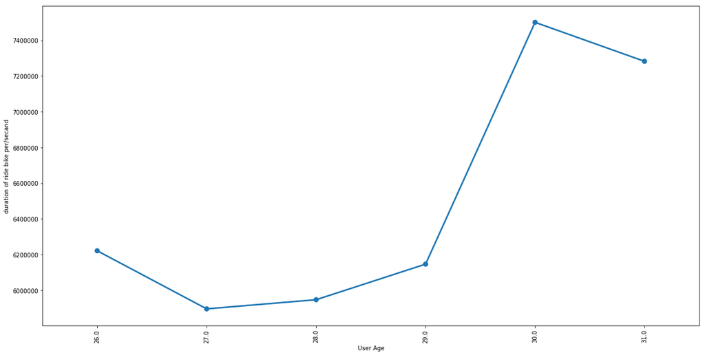

```python
sb.pointplot(data = better_duration, x = 'age', y = 'duration_sec')
plt.xticks(rotation = 90)
plt.xlabel('User Age')
plt.ylabel('duration of ride bike per/secand')
```

```python
count_age.query("age == 30")
```

|  | age | sum of values |
| --- | --- | --- |
| 2 | 30.0 | 8972 |

```python
count_age.query("age == 31")
```

|  | age | sum of values |
| --- | --- | --- |
| 0 | 31.0 | 10236 |

30 and 31 ages is more productive when we talk to duration second; but it is not surprise because approxemately this 2 ages come to ride more than others especialy 31 years old with 10236 person.

```python
count_age_duration['duration_sec'].mean()
```

```
1644541.2266666666
```

```python
count_age_duration['duration_sec'].quantile(.5)
```

```
835143.0
```

```python
duration_mean = count_age_duration[count_age_duration["duration_sec"] >= 1644541.2266666666]
```

```python
duration_median = count_age_duration[count_age_duration["duration_sec"] >= 835143.0]
```

```
Text(0,0.5,'duration of ride bike per/secand')
```

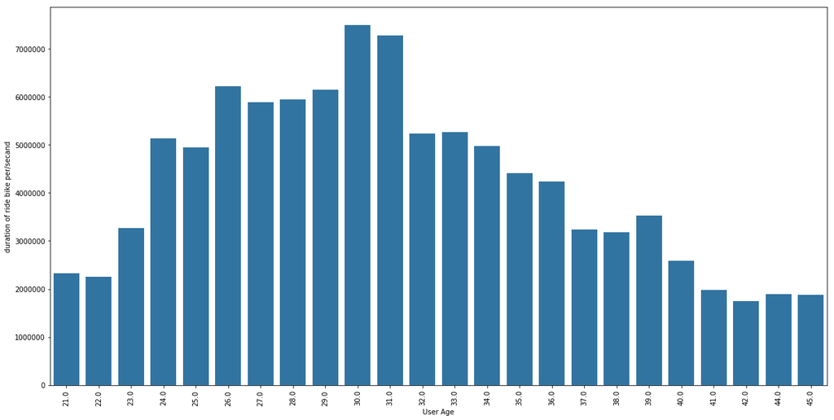

```python
sb.barplot(data = duration_mean, x = 'age', y = 'duration_sec', color = base_color)
plt.xticks(rotation = 90)
plt.xlabel('User Age')
plt.ylabel('duration of ride bike per/secand')
```

from 21 to 45 years old greater than or equal to the mean of duration second.

# Multivariate

```python
customer = df.query("user_type == 'Customer'")
subscriber = df.query("user_type == 'Subscriber'")
```

```python
customer['age'].describe()
```

```
count    19868.000000
mean        33.729292
std          8.674753
min         18.000000
25%         28.000000
50%         34.000000
75%         36.000000
max        141.000000
Name: age, dtype: float64
```

```python
subscriber['age'].describe()
```

```
count    163544.000000
mean         34.249965
std          10.021871
min          18.000000
25%          27.000000
50%          32.000000
75%          39.000000
max         119.000000
Name: age, dtype: float64
```

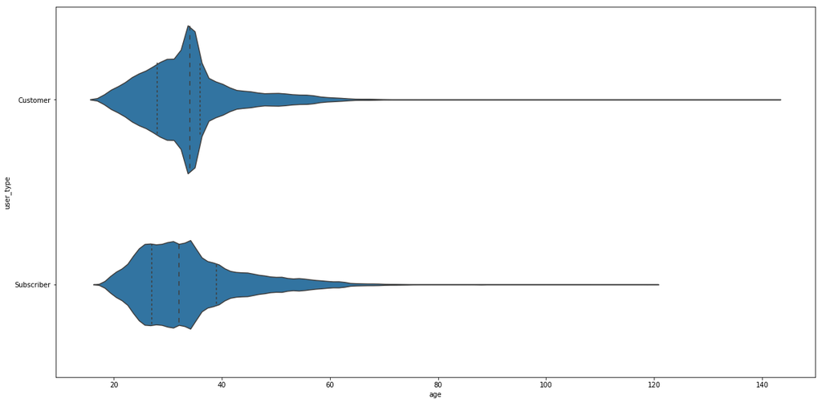

```python
sb.violinplot(data = df, y = 'user_type', x = 'age', color = base_color, inner = 'quartile')
```

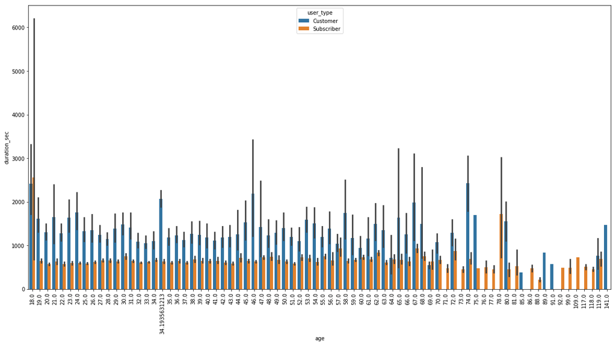

```python
sb.barplot(data=df, x='age',y='duration_sec', hue='user_type')
plt.xticks(rotation=90)
```

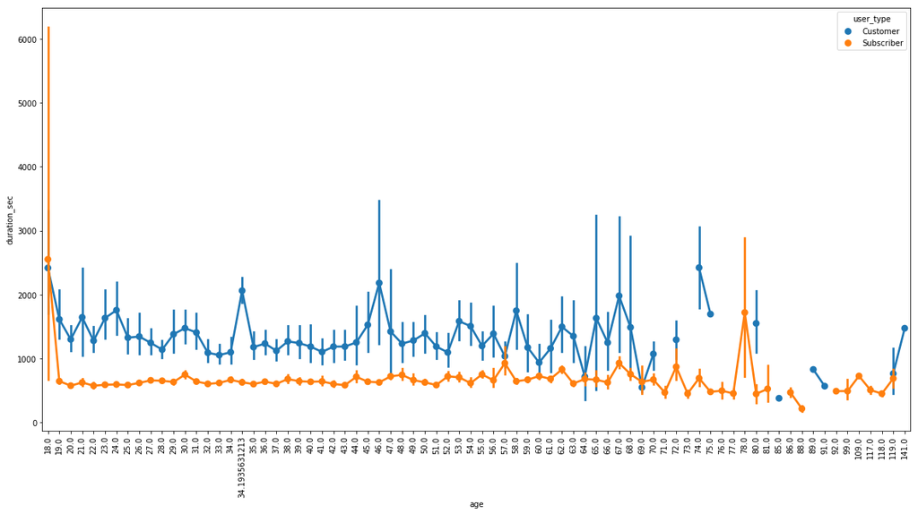

```python
sb.pointplot(data=df, x='age',y='duration_sec', hue='user_type')
plt.xticks(rotation=90)
```

we see now that customers are more productivity when we talk about duration second than subscribers.

```python
from subprocess import call
call(['python', '-m', 'nbconvert', 'Analyze_ab_test_results_notebook.ipynb'])
```